# Diabetes Risk Prediction — Exploratory Analysis and Machine Learning

Vicente Valero

2026-03-25

## 1 Overview

This project analyses a publicly available clinical diabetes dataset from [hbiostat.org](https://hbiostat.org/data) to build and evaluate binary classification models for diabetes risk prediction. The dataset contains clinical, biochemical, and anthropometric measurements from 403 patients.

The central question is whether a combination of routinely available parameters — blood glucose, lipid profile, BMI, blood pressure, and waist-to-hip ratio — can reliably identify individuals at high risk of type 2 diabetes, with a specific focus on models applicable in community pharmacy settings.

## 2 1 — Data Loading and Initial Inspection

```
## First records:
```

|  | id | chol | stab.glu | hdl | ratio | glyhb | location | age | gender | height | weight | frame | bp.1s | bp.1d | bp.2s | bp.2d | waist | hip | time.ppn |
| --- | --- | --- | --- | --- | --- | --- | --- | --- | --- | --- | --- | --- | --- | --- | --- | --- | --- | --- | --- |
| 1 | 1000 | 203 | 82 | 56 | 3.6 | 4.31 | Buckingham | 46 | female | 62 | 121 | medium | 118 | 59 | NA | NA | 29 | 38 | 720 |
| 2 | 1001 | 165 | 97 | 24 | 6.9 | 4.44 | Buckingham | 29 | female | 64 | 218 | large | 112 | 68 | NA | NA | 46 | 48 | 360 |
| 3 | 1002 | 228 | 92 | 37 | 6.2 | 4.64 | Buckingham | 58 | female | 61 | 256 | large | 190 | 92 | 185 | 92 | 49 | 57 | 180 |
| 4 | 1003 | 78 | 93 | 12 | 6.5 | 4.63 | Buckingham | 67 | male | 67 | 119 | large | 110 | 50 | NA | NA | 33 | 38 | 480 |
| 5 | 1005 | 249 | 90 | 28 | 8.9 | 7.72 | Buckingham | 64 | male | 68 | 183 | medium | 138 | 80 | NA | NA | 44 | 41 | 300 |
| 6 | 1008 | 248 | 94 | 69 | 3.6 | 4.81 | Buckingham | 34 | male | 71 | 190 | large | 132 | 86 | NA | NA | 36 | 42 | 195 |

```
##
## Dataset structure:
```

```
## 'data.frame':    403 obs. of  19 variables:
##  $ id      : int  1000 1001 1002 1003 1005 1008 1011 1015 1016 1022 ...
##  $ chol    : int  203 165 228 78 249 248 195 227 177 263 ...
##  $ stab.glu: int  82 97 92 93 90 94 92 75 87 89 ...
##  $ hdl     : int  56 24 37 12 28 69 41 44 49 40 ...
##  $ ratio   : num  3.6 6.9 6.2 6.5 8.9 ...
##  $ glyhb   : num  4.31 4.44 4.64 4.63 7.72 ...
##  $ location: chr  "Buckingham" "Buckingham" "Buckingham" "Buckingham" ...
##  $ age     : int  46 29 58 67 64 34 30 37 45 55 ...
##  $ gender  : chr  "female" "female" "female" "male" ...
##  $ height  : int  62 64 61 67 68 71 69 59 69 63 ...
##  $ weight  : int  121 218 256 119 183 190 191 170 166 202 ...
##  $ frame   : chr  "medium" "large" "large" "large" ...
##  $ bp.1s   : int  118 112 190 110 138 132 161 NA 160 108 ...
##  $ bp.1d   : int  59 68 92 50 80 86 112 NA 80 72 ...
##  $ bp.2s   : int  NA NA 185 NA NA NA 161 NA 128 NA ...
##  $ bp.2d   : int  NA NA 92 NA NA NA 112 NA 86 NA ...
##  $ waist   : int  29 46 49 33 44 36 46 34 34 45 ...
##  $ hip     : int  38 48 57 38 41 42 49 39 40 50 ...
##  $ time.ppn: int  720 360 180 480 300 195 720 1020 300 240 ...
```

The dataset contains **403 patients** and **19 variables**:

| Category | Variables |
| --- | --- |
| Demographic / ID | id, age, gender, location, frame |
| Biochemical | chol, stab.glu, hdl, ratio, glyhb |
| Anthropometric | height, weight, waist, hip |
| Vital signs | bp.1s, bp.1d, bp.2s, bp.2d |
| Other | time.ppn |

## 3 2 — Data Cleaning

```
## Column names:
```

```
##  [1] "id"       "chol"     "stab.glu" "hdl"      "ratio"    "glyhb"
##  [7] "location" "age"      "gender"   "height"   "weight"   "frame"
## [13] "bp.1s"    "bp.1d"    "bp.2s"    "bp.2d"    "waist"    "hip"
## [19] "time.ppn"
```

```
##
## Original dimensions:
```

```
## [1] 403  19
```

```
##
## NAs remaining after cleaning: 0
```

```
## Clean dataset dimensions:
```

```
## [1] 136  19
```

```
##
## Rows removed: 267
```

## 4 3 — Exploratory Data Analysis

### 4.1 3.1 — Cholesterol/HDL Ratio vs Age by Glycaemic Status

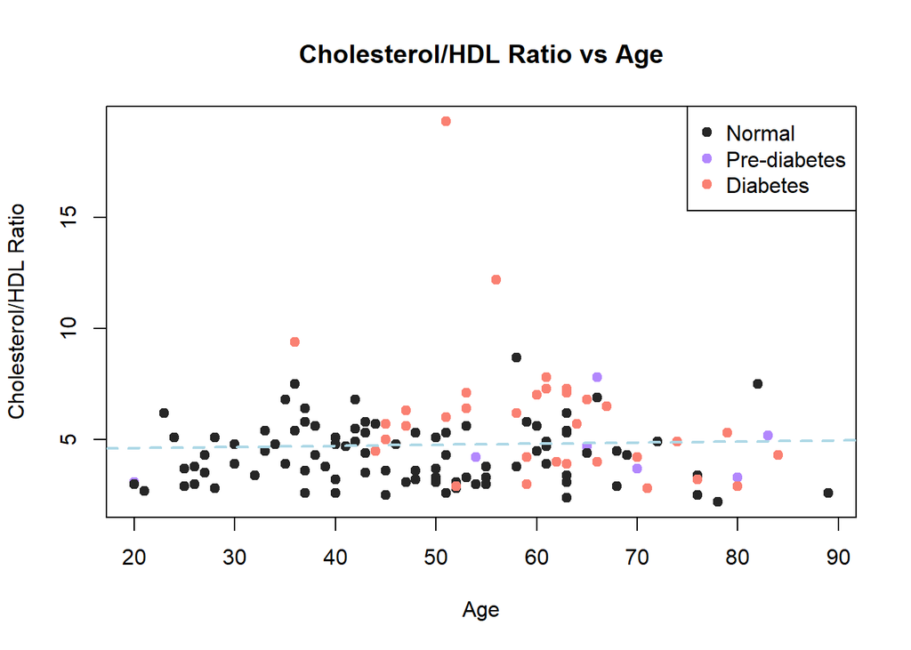

The cholesterol/HDL ratio distribution is right-skewed, with most values between 3 and 6 but a notable tail of individuals exceeding 10, indicating elevated cardiovascular risk. The trend line shows no strong systematic increase of the ratio with age; metabolic factors such as glycaemic control appear more determinant than chronological age for lipid imbalance in this sample.

### 4.2 3.2 — Ratio vs Glycated Haemoglobin (glyhb)

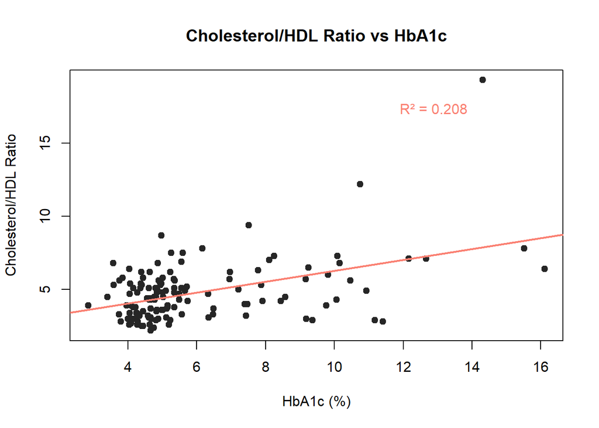

There is a moderate positive association between HbA1c and the cholesterol/HDL ratio (R² = 0.208): poorer glycaemic control tends to coincide with a worse lipid profile, reflecting shared metabolic dysregulation pathways between glucose homeostasis and lipid balance.

### 4.3 3.3 — Ratio by Sex

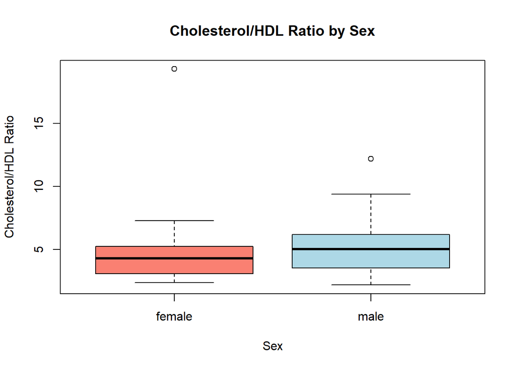

### 4.4 3.4 — Cholesterol Level Distribution

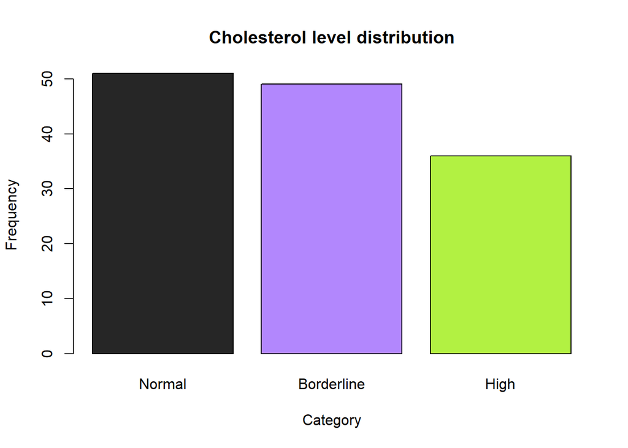

## 5 4 — Probability Analysis

### 5.1 4.1 — Cardiovascular Risk Classification

```
## CARDIOVASCULAR RISK DISTRIBUTION
```

```
##
##      High risk       Low risk  Moderate risk Very high risk
##             40             38             45             13
```

```
##
## Percentages:
```

```
##
##      High risk       Low risk  Moderate risk Very high risk
##          29.41          27.94          33.09           9.56
```

### 5.2 4.2 — Probability Statements

**P(high or very high CV risk):**

```
## P(high or very high CV risk): 38.97 %
```

**P(diabetes | ratio > 5) — conditional probability:**

```
## P(diabetes | ratio > 5): 36.54 %
```

**P(female ∩ moderate CV risk) — joint probability:**

```
## P(female ∩ moderate risk): 22.06 %
```

### 5.3 4.3 — Simulation: Normal Approximation of the Ratio Distribution

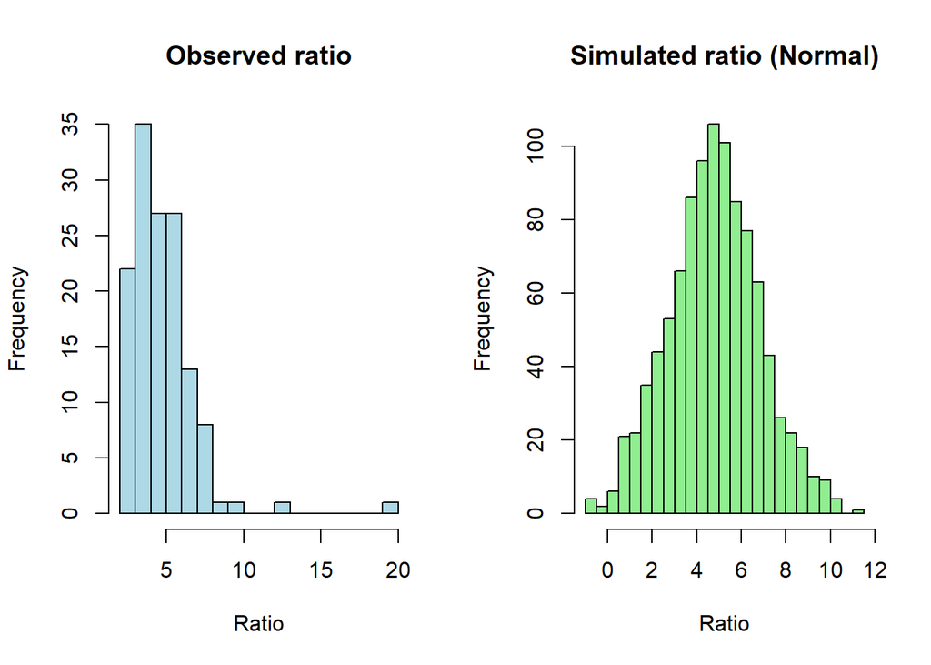

```
## OBSERVED vs SIMULATED
```

```
## Observed mean: 4.76  | Simulated mean: 4.8
```

```
## Observed SD:   2.05  | Simulated SD:   2.03
```

## 6 5 — Machine Learning: Diabetes Classification

Binary outcome: **glyhb ≥ 6.5%** = diabetes (1), otherwise = no diabetes (0).

### 6.1 5.1 — Feature Engineering and Train/Test Split

```
## Variables available: 11 of 11
```

```
##  [1] "age"               "gender"            "chol"
##  [4] "hdl"               "stab.glu"          "bmi"
##  [7] "waist_hip_ratio"   "bp_systolic_mean"  "bp_diastolic_mean"
## [10] "ratio"             "diabetes_binary"
```

```
##
## Rows before cleaning: 136
```

```
## Rows after cleaning:  136
```

```
## Outcome distribution:
```

```
##
##   0   1
## 103  33
```

```
## Diabetes prevalence (glyhb ≥ 6.5%): 24.3 %
```

```
## Training set: 97 observations
## Test set:     39 observations
## Train/test split: 71.3 / 28.7 %
```

### 6.2 5.2 — Model 1: Logistic Regression

```
##
## Call:
## glm(formula = formula_model, family = binomial(), data = train_data)
##
## Coefficients:
##                     Estimate Std. Error z value Pr(>|z|)
## (Intercept)       -10.489296   6.997108  -1.499 0.133850
## age                 0.034465   0.032442   1.062 0.288073
## gendermale          0.139296   0.986114   0.141 0.887667
## chol                0.042105   0.022207   1.896 0.057954 .
## hdl                -0.089669   0.069665  -1.287 0.198044
## stab.glu            0.052305   0.014403   3.632 0.000282 ***
## bmi                 0.065920   0.059139   1.115 0.264997
## waist_hip_ratio     0.660517   5.510987   0.120 0.904598
## bp_systolic_mean   -0.008194   0.024925  -0.329 0.742337
## bp_diastolic_mean   0.005725   0.042778   0.134 0.893535
## ratio              -1.151691   0.814470  -1.414 0.157351
## ---
## Signif. codes:  0 '***' 0.001 '**' 0.01 '*' 0.05 '.' 0.1 ' ' 1
##
## (Dispersion parameter for binomial family taken to be 1)
##
##     Null deviance: 108.540  on 96  degrees of freedom
## Residual deviance:  47.754  on 86  degrees of freedom
## AIC: 69.754
##
## Number of Fisher Scoring iterations: 7
```

```
##                            Variable Coefficient Odds_Ratio
## (Intercept)             (Intercept)    -10.4893     0.0000
## age                             age      0.0345     1.0351
## gendermale               gendermale      0.1393     1.1495
## chol                           chol      0.0421     1.0430
## hdl                             hdl     -0.0897     0.9142
## stab.glu                   stab.glu      0.0523     1.0537
## bmi                             bmi      0.0659     1.0681
## waist_hip_ratio     waist_hip_ratio      0.6605     1.9358
## bp_systolic_mean   bp_systolic_mean     -0.0082     0.9918
## bp_diastolic_mean bp_diastolic_mean      0.0057     1.0057
## ratio                         ratio     -1.1517     0.3161
```

```
##
## Significant predictors (p < 0.05):
## [1] "stab.glu"
```

```
## Confusion Matrix and Statistics
##
##           Reference
## Prediction  0  1
##          0 30  6
##          1  0  3
##
##                Accuracy : 0.8462
##                  95% CI : (0.6947, 0.9414)
##     No Information Rate : 0.7692
##     P-Value [Acc > NIR] : 0.17168
##
##                   Kappa : 0.4348
##
##  Mcnemar's Test P-Value : 0.04123
##
##             Sensitivity : 0.33333
##             Specificity : 1.00000
##          Pos Pred Value : 1.00000
##          Neg Pred Value : 0.83333
##              Prevalence : 0.23077
##          Detection Rate : 0.07692
##    Detection Prevalence : 0.07692
##       Balanced Accuracy : 0.66667
##
##        'Positive' Class : 1
##
##
## Key metrics:
## Accuracy:     84.62 %
## Sensitivity:  33.33 %
## Specificity:  100 %
```

### 6.3 5.3 — Model 2: Random Forest

```
##
## Call:
##  randomForest(formula = formula_model, data = train_data, ntree = 50,      importance = TRUE)
##                Type of random forest: classification
##                      Number of trees: 50
## No. of variables tried at each split: 3
##
##         OOB estimate of  error rate: 10.31%
## Confusion matrix:
##    0  1 class.error
## 0 69  4  0.05479452
## 1  6 18  0.25000000
```

```
##                            0          1 MeanDecreaseAccuracy MeanDecreaseGini
## stab.glu           9.4820298 11.5362404           12.3940229       17.5181310
## age                1.2134806  3.4549718            3.1524615        3.3745269
## bp_diastolic_mean  2.7160637  0.6743620            2.4606605        2.2149487
## bp_systolic_mean   1.2250550  2.4737353            2.3283972        1.7481187
## hdl                0.9127716  0.6822193            1.5946579        1.1303486
## chol              -0.1074054  2.8493654            1.5623679        3.5418988
## bmi                0.5262835  0.7238878            0.7160503        2.3316665
## ratio              0.7700815 -0.8181820            0.4374545        2.9795611
## waist_hip_ratio   -0.2906350  0.6716406            0.4260154        1.4900198
## gender             1.0508537 -1.7786080           -0.3817601        0.2563469
```

```
## Confusion Matrix and Statistics
##
##           Reference
## Prediction  0  1
##          0 30  4
##          1  0  5
##
##                Accuracy : 0.8974
##                  95% CI : (0.7578, 0.9713)
##     No Information Rate : 0.7692
##     P-Value [Acc > NIR] : 0.03572
##
##                   Kappa : 0.6579
##
##  Mcnemar's Test P-Value : 0.13361
##
##             Sensitivity : 0.5556
##             Specificity : 1.0000
##          Pos Pred Value : 1.0000
##          Neg Pred Value : 0.8824
##              Prevalence : 0.2308
##          Detection Rate : 0.1282
##    Detection Prevalence : 0.1282
##       Balanced Accuracy : 0.7778
##
##        'Positive' Class : 1
##
##
## Key metrics:
## Accuracy:     89.74 %
## Sensitivity:  55.56 %
## Specificity:  100 %
```

### 6.4 5.4 — Model Comparison

[figure not shown]

[figure not shown]

**Logistic regression** offers full interpretability: coefficients translate directly into odds ratios with confidence intervals, supporting evidence-based clinical communication. Its main limitation is the linearity assumption, which may underrepresent complex interactions (e.g. age × obesity, glucose × lipids) common in metabolic disease.

For mass screening in community pharmacy, interpretable models with clear clinical thresholds offer better risk-benefit balance. For research or specialist tools, the predictive power of ensemble methods justifies their complexity. Hybrid approaches — combining the transparency of regression with the flexibility of ensemble methods — represent a promising direction.

## 7 6 — Interactive Shiny Application

The app below lets users explore the diabetes dataset interactively, selecting X and Y variables for scatter plots, choosing a colour-by variable (sex or CV risk), and toggling a trend line. A descriptive summary of selected variables is displayed alongside the chart.

```r
library(shiny)
library(ggplot2)

ui <- fluidPage(
  titlePanel("Diabetes dataset explorer"),

  sidebarLayout(
    sidebarPanel(
      h4("Select variables:"),

      selectInput("var_x", "X axis:",
                  choices  = c("age", "chol", "stab.glu", "hdl",
                               "ratio", "glyhb", "weight", "waist", "hip"),
                  selected = "age"),

      selectInput("var_y", "Y axis:",
                  choices  = c("age", "chol", "stab.glu", "hdl",
                               "ratio", "glyhb", "weight", "waist", "hip"),
                  selected = "ratio"),

      selectInput("color_by", "Colour by:",
                  choices  = c("None"       = "none",
                               "Sex"        = "gender",
                               "CV risk"    = "cv_risk"),
                  selected = "gender"),

      checkboxInput("trend_line", "Show trend line", value = TRUE),
      hr(),
      helpText("Lipid and metabolic profile data (NA-cleaned).")
    ),

    mainPanel(
      plotOutput("scatter_plot"),
      hr(),
      h5("Summary statistics for selected variables:"),
      verbatimTextOutput("summary_stats")
    )
  )
)

server <- function(input, output) {

  output$scatter_plot <- renderPlot({
    p <- ggplot(Diabetes_clean, aes_string(x = input$var_x, y = input$var_y))

    if (input$color_by != "none") {
      p <- p + aes_string(color = input$color_by) +
        geom_point(size = 3, alpha = 0.7) +
        labs(color = input$color_by)
    } else {
      p <- p + geom_point(size = 3, color = "steelblue", alpha = 0.7)
    }

    if (input$trend_line) {
      p <- p + geom_smooth(method = "lm", se = FALSE, color = "darkred")
    }

    p + theme_minimal() +
      labs(title = paste(input$var_y, "vs", input$var_x),
           x     = input$var_x,
           y     = input$var_y)
  })

  output$summary_stats <- renderPrint({
    vars <- c(input$var_x, input$var_y)
    if (input$color_by != "none") vars <- c(vars, input$color_by)
    subset_data <- Diabetes_clean[, vars, drop = FALSE]

    cat("STATISTICAL SUMMARY\n")
    if (input$color_by != "none") {
      cat("Categorical variable:", input$color_by, "\n")
      print(table(subset_data[[input$color_by]]))
      cat("\n")
    }
    cat("Numeric variables:\n")
    print(summary(subset_data[, sapply(subset_data, is.numeric), drop = FALSE]))
  })
}

shinyApp(ui = ui, server = server)
```

## 8 7 — Conclusions

**Limitations** include the absence of lifestyle variables (diet, physical activity, family history), a moderate sample size, and substantial missing data in blood pressure variables. Future work should incorporate multiple imputation, cross-validation, and external validation on independent cohorts to improve generalisability.

[output not shown]